# R Advanced Course 2025

Gene Set Enrichment Analysis (GSEA)

Ulrike Göbel

Bioinformatics Core Facility CECAD

2025-11-20

## Slides & Code

[figure not shown]

- *[f]* Full screen
- *[o]* Slide Overview
- *[c]* Notes
- *[h]* help

### git repo

[R-Advanced](https://github.com/CECADBioinformaticsCoreFacility/Advanced_R_Course_2025)

### Clone repo

`git clone https://github.com/CECADBioinformaticsCoreFacility/Advanced_R_Course_2025.git`

### Slides Directly

https://github.com/CECADBioinformaticsCoreFacility/Advanced_R_course_2025

**Session 6 :: Gene Set Enrichment Analysis**

## Gene Set Enrichment Analysis – The Basic Algorithm

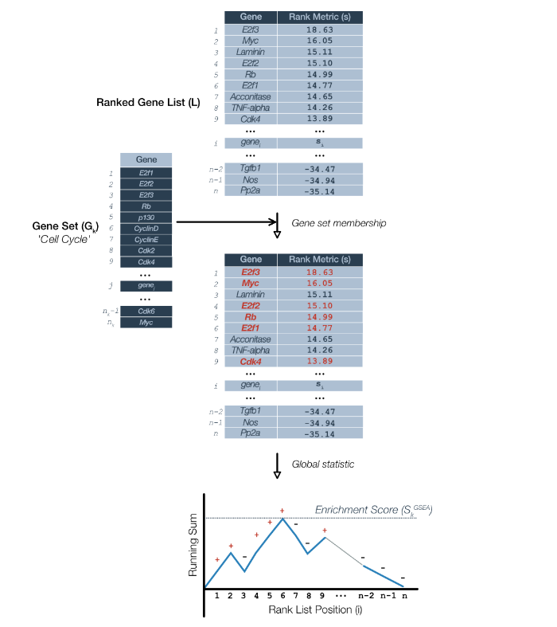

**Input:**

- a ranked gene list
- one gene set (e.g. GO term) at a time

**Algorithm:**

- **Step 1:** Mark members of the gene set in the list
- **Step 2:** “Walk” down the list from top to bottom, and do at each list position:
  - if the current gene is in the gene set, increment a running sum
  - if it is not, decrement the sum

**Output:**

- **Enrichment Score (ES):** the largest absolute sum value encountered on the walk
- **Normalized Enrichment Score (NES):** The ES corrected for the effect of gene set size

## Variants and Implementations – Counting Options

- **The ranking metric:**

  This can be anything, but in the context of DESeq2 analysis two choices prevail:
  - $-log10(pvalue) * sign(log2FoldChange$ `# NOT padj !`
  - the Wald statistic (the $stat$ column in a result table)
- **The per-step increment/decrement:**
  - The general form is
    - increment: $|s_i|^{\alpha}$, where $s_i$ is the ranking metric at position i
    - decrement: $-1$

    [Increment and decrement are in addition weighted by the total number of hits and misses in the ranked gene list.]
  - If $\boldsymbol{\alpha} \mathbf{\; = 0}$, then the expression reduces to simple counting of both hits and misses (the basic algorithm)  
    In this case the ES follows a **Kolmogorov-Smirnov Null distribution, which directly yields p-values**.
  - If $\boldsymbol{\alpha} \boldsymbol{\neq} \mathbf{0}$, then a **Null distribution** of the ES must be constructed **by permutations**.

Permutations are time-consuming, but $\boldsymbol{\alpha} \boldsymbol{\neq} \mathbf{0}$ **is a conceptual improvement: it allows to weight a match at position i by** $|s_i|$ **.**

## Variants and Implementations – Permutations Options

**`Sample Permutation:`**

for **`n = 1:N`** do

- **randomly shuffle the dataset’s sample labels**
- **re-compute the ranking metric**, using the shuffled dataset (this means to **re-run DESeq2!**)
- **re-compute the GSEA scores**, using the re-computed ranking metric

**`Pro:`**

- **`it fits naturally with the typical experimental question:`**  
  **Do different sample labels = different experimental conditions imply differential use of functional gene sets?**
- **`it uses the native gene sets`**

**`Con:`**

- For a reasonably large N (>= 1000) it **`TAKES A LOT OF TIME!`**

## Variants and Implementations – Permutations Options

**`Gene Set Permutation`**

for **`n = 1:N`** do

for **`each gene set g`** do

- **construct a randomized copy**, by drawing overlap(g, L) genes from the ranked gene list L

$\square$

- **re-compute the GSEA scores** , using the randomized gene sets and the original dataset

$\square$

**`Pro:`**

- **`MUCH FASTER`** **than sample permutation** (dependent on the implementation)
- therefore it is **`today the de facto standard`**

**`Con:`** (-> next slide!)

## Variants and Implementations – Permutations Options

**`Con:`**

**Gene Set Permutation is justified by the following line of argument:**

- **a random subset of the ranked genes is not expected to be significantly differentially expressed between experimental conditions**
- a **Null distribution of the GSEA scores of a native gene set S** can therefore be constructed like so:
  - randomly draw a subset of size(S) from the ranked genes and determine its GSEA score
  - repeat N times (N large)
- use this distribution to define a **p-value of “no differential expression” for S**

**The weak point of this line of argument: gene-gene correlations!**

- **native gene sets are co-evolved functional units**, which are often induced or repressed as a whole
- **in native sets, it is not unlikely to see several or many member genes vary in the same direction between conditions**
- **in random sets, this is much more unlikely**
- hence **p-values from Gene Set Permutation may be inflated**: even a moderate differential expression may count as highly significant

**`Yet .. in practice, Gene Set Permutation GSEA does discover interesting gene sets,`**

**`-- and it is fast!`**

## Variants and Implementations – FGSEA

Several R packages either use or implement variants of the [**Fast Gene Set Enrichment Analysis (FGSEA) algorithm**](https://www.biorxiv.org/content/10.1101/060012v3), which implements a fast approximation to the naive gene-sampling approach of Gene Set Permutation:

- [`fgsea`](https://github.com/alserglab/fgsea) is the original implementation corresponding to the paper (see above link)
- [`clusterProfiler`](https://github.com/YuLab-SMU/clusterProfiler) uses `fgsea` in several database interfacing packages like `gseGO`, `gseKEGG`, and others

Both packages are also available on Bioconductor.

## Variants and Implementations – MSigDB GSEA-R

**This is the original algorithm corresponding to the [Subramanian et al. 2005 paper](https://www.pnas.org/doi/10.1073/pnas.0506580102).** The original idea focused on **Sample Permutation**, arguing that Gene Set Permutation overestimates significance levels by ignoring gene-gene correlations. However **Gene Set Permutation was also provided** as an option, for cases with too few samples to allow a meaningful Sample Permutation.

**An R package version of the software used to be distributed by [MSigDB (Broad Institute)](https://www.gsea-msigdb.org/gsea/msigdb), however this has been recently discontinued.** The code is still provided [here](https://github.com/GSEA-MSigDB/GSEA_R), but with the disclaimer `R-GSEA remains unsupported by the GSEA-MSigDB Team`. MSigDB provides its implementation as a [Java application](https://www.gsea-msigdb.org/gsea/downloads.jsp).

## Variants and Implementations – piano

[`piano`](https://www.bioconductor.org/packages/devel/bioc/vignettes/piano/inst/doc/piano-vignette.pdf) is another Bioconductor package, first published in 2013. It offers **GSEA with both Sample Permutation and Gene Set Permutation**, among a range of other methods.

**For the Sample Permutation test, the user must pre-compute all permuted data runs**. A brute force computation on my laptop of DESeq2 results for 460 genotype permutations of the practice dataset took about 1 day (this could surely be improved). The **piano result** with this input was **superficially similar to an fgsea Gene Set Permutation result, which takes a few minutes. This seems to suggest that sample permutation on a large dataset may not be worthwhile** – but one would need to dig deeper to see whether there are benefits of this statistically more sound, but time consuming method.

## GSEA in Action

We have seen that **the “~ genotype” model yields too few significant genes to produce a significant ORA result** with the full matrix, and in most cases also after subsetting by tissue.

**GSEA may be more sensitive to a weak signal, because it uses a pre-*ranked* list of all genes of interest**, rather than a pre-*selected* set of (significant) genes. **Prioritization criteria are coded in the ranking metric** (usually the degree of differential expression between experimental groups).

**Important**

The consistent clustering of a gene set’s members in a sub-significant region of the ranked list may be a stronger hint at a biological role of the gene set than a few isolated member genes with significant differential expression.

We will see that a pure “~ genotype” effect, without explicitly modeling other factors, can indeed manifest in the form of exactly this sub-significant non-randomness.

## GSEA in Action – Subsetting the Data Matrix to Liver Only

We subset the full data matrix to retain liver samples only (see function **subset_counts() in [this script](https://github.com/CECADBioinformaticsCoreFacility/Advanced_R_course_2025/blob/master/rnaseq_ProjectName/R/functions_sessions2_4.R)** ). This removes the excessive variance due to tissue differences.

```r
library("org.Mm.eg.db")
dds_liver <- subset_counts(dds_genotype,level_list=list(tissue="liver"),
                           include=TRUE, refit=TRUE)
res_liver.genotype <- results(dds_liver,
                              name="genotype_nmrhas2_vs_creer"
                              )
table(res_liver.genotype$padj <= 0.05,
      useNA="ifany")
```

```
FALSE  TRUE  <NA>
19222    18 13664
```

Yet, only 18 genes are significantly differently expressed between transgenic and wildtype animals – only two more genes than with the full dataset.

## GSEA in Action – Try ORA First, For Comparison

Still it is possible that this small group of genes belongs to shared, meaningful pathways.  
Let’s try an ORA analysis first (see Session 5):

```r
liver_sig_genes_up <-
  res_liver.genotype |> as.data.frame() |>
  filter(!is.na(padj),padj <= 0.05, log2FoldChange > 0)|>
  tibble::rownames_to_column("symbol") |> pull(symbol)

liver_sig_genes_dn <-
  res_liver.genotype |> as.data.frame() |>
  filter(!is.na(padj),padj <= 0.05, log2FoldChange < 0)|>
  tibble::rownames_to_column("symbol") |> pull(symbol)

universe <-
  res_liver.genotype |> as.data.frame() |>
  filter(!is.na(padj)) |> rownames()
```

```r
ego_liver_genotype_0.05_up <-
     runORA(liver_sig_genes_up,universe,org.Mm.eg.db,"SYMBOL")
ego_liver_genotype_0.05_dn <-
     runORA(liver_sig_genes_dn,universe,org.Mm.eg.db,"SYMBOL")
```

## GSEA in Action – Try ORA First, For Comparison

```r
## How many significantly UP-regulated terms were found per GO ontology?
sapply(ego_liver_genotype_0.05_up,
       function(x) x |> #as.data.frame() |>
                   filter(p.adjust <= 0.05) |> nrow()
       )
```

```
 BP  MF  CC
228  25   0
```

Looks as if quite some terms of the Biological Process ontology are up-regulated … however …

```r
## All terms found are indeed based on a tiny set of genes:
sapply(ego_liver_genotype_0.05_up$BP$geneID,
       strsplit,'/'
       ) |> unlist() |> unique()
```

```
[1] "Irs2"   "Bmp2"   "Dnah11" "Nfil3"
```

```r
sapply(ego_liver_genotype_0.05_up$MF$geneID,
       strsplit,'/'
       ) |> unlist() |> unique()
```

```
[1] "Irs2"   "Bmp2"   "Dnah11"
```

```r
## All these terms share only 4 genes with our universe, and
## one or two of these are among the significant genes (see the
## GeneRatio column). These are very likely spurious matches,
## especially as the "Description"s look unrelated to liver biology.
```

## GSEA in Action – Try ORA First, For Comparison

```r
## How many significantly DOWN-regulated terms were found per GO ontology?
sapply(ego_liver_genotype_0.05_dn,
       function(x) x |> #as.data.frame() |>
                   filter(p.adjust <= 0.05) |> nrow()
       )
```

```
BP MF CC
 0  0  0
```

Not a single term in any ontology!

## GSEA in Action – Can It Do Better?

```r
L <- (res_liver.genotype |> as.data.frame() |>
     filter(!is.na(padj)) |> arrange(desc(stat)) |>
     as.matrix())[,"stat"]
gse_liver_genotype_0.05 <- runGSEA(L,org.Mm.eg.db,"SYMBOL")
```

```r
## How many significant terms were found per GO ontology?
sapply(gse_liver_genotype_0.05,
       function(x) x |> #as.data.frame() |>
                   filter(p.adjust <= 0.05) |> nrow()
       )
```

```
  BP   MF   CC
1385  125  120
```

Indeed: GSEA finds much more significant terms!

## GSEA in Action – Can It Do Better?

The **“NES” column** in the GSEA result table contains the **Normalized Enrichment Score**. Given our ranking by the Wald test statistic, a positive NES suggests up-regulation of its genes in nmrHAS2 compared to creER, while a negative NES suggests down-regulation.

```r
## Number of significant terms with positive NES ..
sig_up <-
  sapply(gse_liver_genotype_0.05,
         function(x) x |> #as.data.frame() |>
                     filter(p.adjust <= 0.05, NES > 0),
         simplify=FALSE
         )
sapply(sig_up, nrow)
```

```
 BP  MF  CC
376  40  30
```

```r
## based on how many genes?
sapply(sig_up,
       function(x) ## core_enrichment is the equivalent of geneID in GSEA
                    sapply(x$core_enrichment,
                           strsplit,'/'
                          ) |>
                    unlist() |> unique() |> length()
)
```

```
  BP   MF   CC
2267  670  920
```

## GSEA in Action – Can It Do Better?

The **“NES” column** in the GSEA result table contains the **Normalized Enrichment Score**. Given our ranking by the Wald test statistic, a positive NES suggests up-regulation of its genes in nmrHAS2 compared to creER, while a negative NES suggests down-regulation.

```r
## Number of significant terms with negative NES ..
sig_dn <-
  sapply(gse_liver_genotype_0.05,
         function(x) x |>
                     filter(p.adjust <= 0.05, NES < 0),
         simplify=FALSE)

sapply(sig_dn, nrow)
```

```
  BP   MF   CC
1009   85   90
```

```r
## based on how many genes?
sapply(sig_dn,
       function(x) ## core_enrichment is the equivalent of geneID in GSEA
                    sapply(x$core_enrichment,
                           strsplit,'/'
                          ) |>
                    unlist() |> unique() |> length()
)
```

```
  BP   MF   CC
2481 1372 1534
```

## GSEA in Action – Visualizing the Result

A typical “GSEA plot”, as introduced by the Broad Institute implementation, can be drawn by `enrichplot::gseaplot2()`.

`gseaplot2()` draws the ES curve of one or more gene sets. Let’s draw the first sig_up and the first sig_dn term:

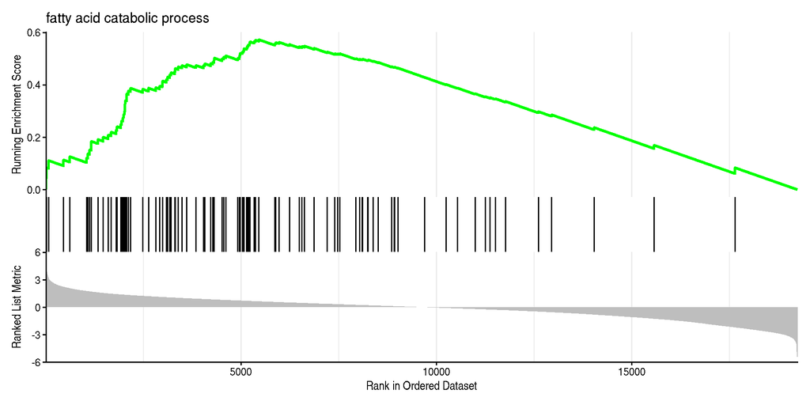

```r
enrichplot::gseaplot2(sig_up$BP,
                      geneSetID = sig_up$BP$ID[1],
                      title = sig_up$BP$Description[1])
```

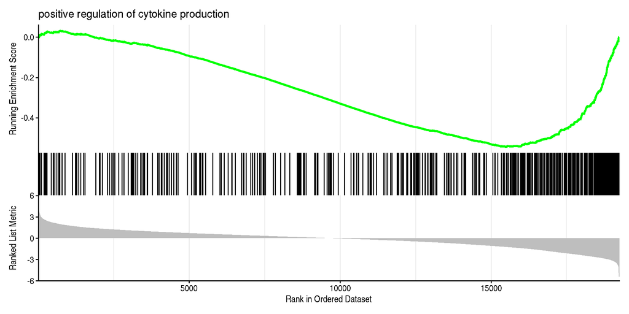

```r
enrichplot::gseaplot2(sig_dn$BP,
                      geneSetID = sig_dn$BP$ID[1],
                      title = sig_dn$BP$Description[1])
```

Observe

- Although the adjusted p-values of both terms are highly significant (1.8^{-12} and 3.8^{-31}), the peaks of the ES curves are not very close to the top and the bottom of the ranked list.  
  **The main contribution to the peaks surely comes from sub-significant, yet clustering, genes** (on the x axis).

## GSEA in Action – Visualizing the Result

With more than ~5 ES curves overplotted on the same canvas, detailed GSEA plots become hard to read. Function `emapplot()` provides a bird’s eye view, completely disregarding the details on why individual terms are significant, but rather plotting a **semantic similarity graph of many significant terms at once**.

For **sig_up:**

```r
enrichplot::emapplot(enrichplot::pairwise_termsim(sig_up$BP),
                     showCategory = 150)
```

[see next slide for output]

## GSEA in Action – Visualizing the Result

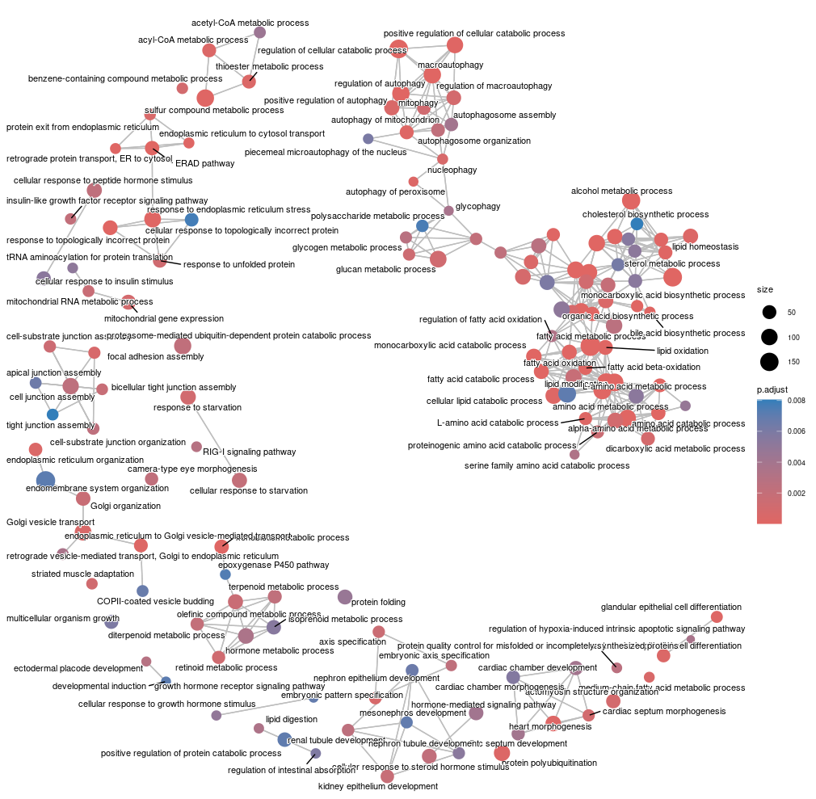

The top 150 up-regulated terms are characterized by **a dense metabolic cluster plus more loosely connected terms, often ER-related**.

## GSEA in Action – Visualizing the Result

With more than ~5 ES curves overplotted on the same canvas, detailed GSEA plots become hard to read. Function `emapplot()` provides a bird’s eye view, completely disregarding the details on why individual terms are significant, but rather plotting a **semantic similarity graph of many significant terms at once**.

For **sig_dn:**

```r
enrichplot::emapplot(enrichplot::pairwise_termsim(sig_dn$BP),
                     showCategory = 150)
```

[see next slide for output]

## GSEA in Action – Visualizing the Result

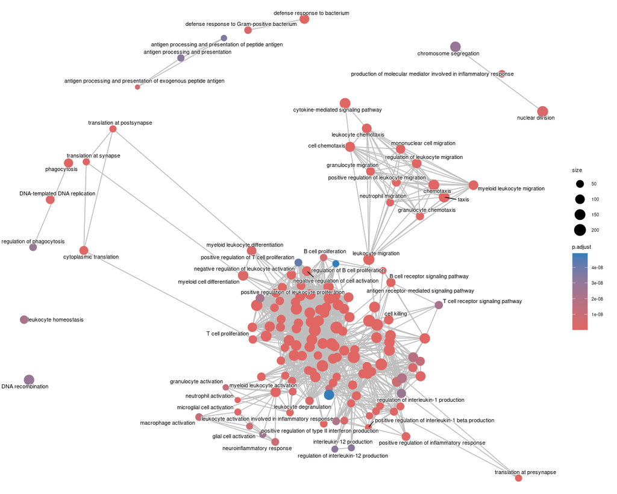

The top 150 down-regulated terms are dominated by **a large, dense cluster of immune terms (mostly regulatory and signaling) and a smaller cluster of terms related to immune cell migration**.

**NOTE:** there are much more significant “down” than “up” terms. As a consequence **a hard threshold of 150 terms cuts at a much smaller p.adjust value in the “down” list than in the “up” list!**

## Core Enrichment Genes and DESeq2 Adjusted P-Values

**The “core_enrichment” genes of a term contribute most to the deviation of the running sum from zero.** We would like to see where they are located in the distribution of DESeq2 adjusted p-values.

Plotting of detailed information on individual terms’ genes is restricted to a few terms at a time. Here is a function to ease inspecting multiple such subsets: it returns a random subset of terms with GSEA p.adjust in a specified numerical range, which can later serve as plotting input:

```r
term_by_GSEA_p.adjust <-
  function(res, # a gseaResult object
           min_p=1e-10, max_p=0.05, nterms=1) {
    sample((res |> #as.data.frame() |>
           filter(p.adjust >= min_p,
                  p.adjust <= max_p))$ID, ## pull does not work with gseaResult
           size=nterms, replace=FALSE)
  }
```

## Core Enrichment Genes and DESeq2 Adjusted P-Values

This (long! – scroll down) function draws the plots:

It calls `term_by_GSEA_p.adjust()`, then for each selected term (1) plots DESeq2 “stat” (GSEA’s rank metric) vs -log10(DESeq2 “padj”), and (2) distinguishes the core enrichment genes (“core”) and the remaining genes (“bg” = background) by color.

```r
plot_terms <-
  function(res_DE,  # a DESeqDataSet object
           res_GSEA, # a gseaResult object
           min_p=1e-10, max_p=0.05, nterms=6
  ) {

  terms <- ## select 6 terms at a time
    term_by_GSEA_p.adjust(res_GSEA,
                          min_p = min_p,
                          max_p = max_p,
                          nterms= nterms)
  # get the Descriptions of the terms:
  D <- setNames(res_GSEA[terms,"Description"],
                terms)
  # get the adjusted GSEA p-values of the terms:
  P <- setNames(res_GSEA[terms,"p.adjust"],
                terms)
  # get the NES of the terms:
  N <- setNames(res_GSEA[terms,"NES"],
                terms)
  # get the core_enrichment genes of the terms:
  C <- setNames(res_GSEA[terms, "core_enrichment"],
                terms)

  # the ranking metric used for GSEA is stored in slot @geneList of the gseaResult object
  L <- res_GSEA@geneList

  # the DESeq2 result in the same order as L:
  res_DE <- res_DE[names(L),] |> as.matrix()
  # converting to matrix() above allows to extract a *named* column:
  minusLog10_padj <- -log10(res_DE[,"padj"])


  # construct the ggplot() input data.frame():
  df <-
   Reduce(rbind,
          lapply(terms,
                 function(t) data.frame(
                                term = paste0(t, "\n(",D[t],")\n",
                                              "p.adjust=",signif(P[t],digits=2)),
                                x = L,
                                minusLog10_padj = minusLog10_padj,
                                core_enrichment =
                                  factor(ifelse(
                                    names(minusLog10_padj) %in% strsplit(C[t],"/")[[1]],
                                    "core", "bg"
                                  ))
                             )
           )
  )

  colors <- c(bg="darkgrey",core="orange")
  sizes  <- c(bg=0.1,core=1)
  ggplot(df) +
  geom_point(aes(x=x,y=minusLog10_padj, color=core_enrichment, size=core_enrichment)) +
  geom_hline(yintercept = -log10(0.05)) + # add indicator line for p=0.05
  scale_color_manual(values=colors) +
  scale_size_manual(values=sizes) +
  scale_x_reverse() + # plot x-axis from positive to negative values
  theme(plot.title = element_text(size=10)) +
  xlab("stat (DESeq2 Wald statistic)") +
  ylab("-log10(DESeq2 padj)") +
  facet_wrap(~term)   # one plot per term
}
```

Try it out [output next slide] – do it several times, to get an impression of the variance!

```r
plot_terms(res_DE = res_liver.genotype,
           res_GSEA = sig_dn$BP,
           max_p = 0.01,
           nterms = 9)
```

## Core Enrichment Genes and DESeq2 Adjusted P-Values

[figure not shown]

`A sample of GSEA up-regulated terms:` More significant terms are more clustered and/or include significant DE genes.

## Core Enrichment Genes and DESeq2 Adjusted P-Values

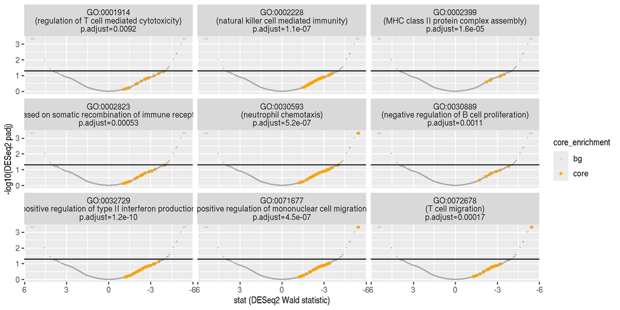

`A sample of GSEA down-regulated terms:` More significant terms are more clustered and/or include significant DE genes.

## Summary

- **Overrepresentation Analysis (ORA) and Gene Set Enrichment Analysis (GSEA) are in many respects complementary approaches to functional enrichment analysis:**
  - ORA pre-selects genes (typically based on significant differential expression) and examines the selected list for an over-representation of functional terms
  - GSEA scores one functional term at a time, both by its member genes’ position on a rank metric (which encodes degree and direction of differential expression), and by the degree of clustering of the genes on the metric. Notably a strong clustering of many genes (=high consistency) can make up for a sub-significant position on the metric.
- **For cases with few significant differentially expressed genes (like the nmrHAS2 genotype effect in the liver), GSEA can still recover sub-significant but consistent enrichments:**
  - down-regulation of immune terms (in concordance with the study authors)
  - up-regulation of metabolic terms
  - neither of these had been apparent with ORA
- **Caveat**: GO terms are embedded in a parent-child network, where **“parent terms” (super-concepts) can encompass several “child terms” (sub-concepts)**. Especially in well-researched areas like the immune system this graph of relationships can be dense. As “children” are by definition similar to their “parents”, **they can be expected to cluster in similar areas of the GSEA rank metric, which may artificially boost scores**. In the present example this effect has been ignored.